# ✏️ W08 Summative

Author

60775

# Part 1: Predicting Next-Month Gold Returns

#### Introduction:

In this part, I will build a lnear regression model compared with an alternative linera regression model to predict next-month gold returns using macro-financial indicators. This is because the dataset we use is majorly measured as continous, numerical data.

## 1.1 Importing Libraries and Dataset

```python
import pandas as pd
import numpy as np
import matplotlib.pyplot as plt
import seaborn as sns
from sklearn.preprocessing import StandardScaler
from sklearn.model_selection import train_test_split
from sklearn.linear_model import LinearRegression, LogisticRegression
from sklearn.metrics import r2_score, mean_squared_error, mean_absolute_error
import statsmodels.api as sm
```

## 1.2 Load and inspect the Dataset

```python
df = pd.read_csv("/Users/leolyu/Desktop/大三/DS202/Summative 1/Raw data/gold_price_prediction_dataset.csv")

nfci = pd.read_csv("/Users/leolyu/Desktop/大三/DS202/Summative 1/Raw data/nfci-data-series-csv.csv")

# Check the shape of the dataset
print(f"Dataset shape: {df.shape}")
print(f"NFCI dataset shape: {nfci.shape}")
# Check the first few rows of the dataset
df.head()
nfci.head()
```

```
Dataset shape: (278, 16)
NFCI dataset shape: (2875, 7)
```

|  | Friday_of_Week | NFCI | ANFCI | Risk | Credit | Leverage | Nonfinancial_Leverage |
| --- | --- | --- | --- | --- | --- | --- | --- |
| 0 | 01/08/1971 | 0.589720 | 0.513764 | 0.618021 | -1.121216 | -1.030956 | -1.408558 |
| 1 | 01/15/1971 | 0.621620 | 0.577080 | 0.647326 | -1.123034 | -1.048829 | -1.425233 |
| 2 | 01/22/1971 | 0.658645 | 0.658582 | 0.682124 | -1.126147 | -1.065343 | -1.440210 |
| 3 | 01/29/1971 | 0.699330 | 0.748793 | 0.721031 | -1.131016 | -1.079857 | -1.453131 |
| 4 | 02/05/1971 | 0.742389 | 0.838376 | 0.762956 | -1.138125 | -1.091881 | -1.463693 |

## 1.3.1 Target Variable Construction

```python
# Create the variable 'gold_return' as the percentage change in gold price from the previous month
df['gold_return'] = 100 * (df['gold_price'] - df['gold_price'].shift(1)) / df['gold_price'].shift(1)

#Then create the target variable indicating the gold price in next month
df['gold_target'] = df['gold_return'].shift(-1)

#Visually verify the gold_return and gold_target is correcttly added to the dataframe
print(df.head())
```

```
         date  gold_price  MOVE_index  msci_emerging_markets  msci_world  \
0  2003-01-01       369.1      110.89                    NaN         NaN
1  2003-02-01       350.3      105.36                    NaN         NaN
2  2003-03-01       336.9      112.09                    NaN         NaN
3  2003-04-01       339.4       89.27                    NaN         NaN
4  2003-05-01       365.6       99.81                    NaN         NaN

     sp_gsci  euro_area_inflation_expectations  us_inflation_expectations  \
0  4064.0171                               NaN                        2.7
1  4556.6831                               NaN                        3.2
2  3900.0139                               NaN                        3.8
3  3660.6641                               NaN                        2.7
4  4011.6370                               NaN                        2.5

   commodity_equity_volatility  us_10y_yield  brent_price  \
```

[output cut: 19 more lines]

## 1.3.2 Real Yield Construction

```python
# Create the variable 'real_yield' as the difference between the 10-year US Treasury yield and the US inflation rate
df['real_yield'] = df['us_10y_yield'] - df['us_10y_breakeven_inflation']
```

The real yield is an important factor in gold price prediction because higher real yields can make bonds more attractive than gold, which does not pay interest. This can lead to a decrease in demand for gold and thus lower gold prices. Conversely, lower real yields can make gold more attractive as an investment, potentially driving up its price.

## 1.3.3 Integrate Financial Conditions

```python
# Converts the string dates into datetime objects
nfci['Friday_of_Week'] = pd.to_datetime(nfci['Friday_of_Week'])

# Extract just the year-month
nfci['month'] = nfci['Friday_of_Week'].dt.to_period('M')

# Aggregate using the mean value for each month
nfci_monthly = nfci.groupby('month')['NFCI'].mean().reset_index()
```

Taking average is a conventional method for aggregation that provides a central tendency of the data.

```python
 # Convert df's date column to the same month-year format
df['month'] = pd.to_datetime(df['date']).dt.to_period('M')

# Merge the two dataframes on the month column
df = pd.merge(df, nfci_monthly, on='month', how='left')
```

We use a left merge to ensure we won’t accidentally lose rows from the main df dataset.

## 1.3.4 Dataset Assessment

```python
# Check the time coverage and missingness
print(df['date'].min())   # start of time coverage
print(df['date'].max())   # end of time coverage
print(df.isnull().sum())  # missing values per column
df.info()          # overall dataset summary
```

```
2003-01-01
2026-02-01
date                                 0
gold_price                           0
MOVE_index                           0
msci_emerging_markets               13
msci_world                          19
sp_gsci                              0
euro_area_inflation_expectations    14
us_inflation_expectations            1
commodity_equity_volatility          1
us_10y_yield                         1
brent_price                          1
us_10y_breakeven_inflation           1
usd_broad_index                     37
world_trade_volume                   3
world_industrial_production          3
gscpi                                1
gold_return                          1
gold_target                          1
real_yield                           1
month                                0
NFCI                                 0
dtype: int64
<class 'pandas.core.frame.DataFrame'>
RangeIndex: 278 entries, 0 to 277
Data columns (total 21 columns):
 #   Column                            Non-Null Count  Dtype
---  ------                            --------------  -----
 0   date                              278 non-null    object
 1   gold_price                        278 non-null    float64
 2   MOVE_index                        278 non-null    float64
 3   msci_emerging_markets             265 non-null    float64
 4   msci_world                        259 non-null    float64
 5   sp_gsci                           278 non-null    float64
 6   euro_area_inflation_expectations  264 non-null    float64
 7   us_inflation_expectations         277 non-null    float64
 8   commodity_equity_volatility       277 non-null    float64
 9   us_10y_yield                      277 non-null    float64
 10  brent_price                       277 non-null    float64
 11  us_10y_breakeven_inflation        277 non-null    float64
 12  usd_broad_index                   241 non-null    float64
 13  world_trade_volume                275 non-null    float64
 14  world_industrial_production       275 non-null    float64
 15  gscpi                             277 non-null    float64
 16  gold_return                       277 non-null    float64
 17  gold_target                       277 non-null    float64
 18  real_yield                        277 non-null    float64
 19  month                             278 non-null    period[M]
 20  NFCI                              278 non-null    float64
dtypes: float64(19), object(1), period[M](1)
memory usage: 45.7+ KB
```

Key observations:

- All predictors are numerical, which means no encoding is needed.
- The outcome variable is continuous, which is suitable for linear regression.
- The missing values are distributed unevenly across columns. This suggests that the missing data may not be completely random and may require explicit handling.

```python
df[df['usd_broad_index'].isna()][['date', 'usd_broad_index']]
```

|  | date | usd_broad_index |
| --- | --- | --- |
| 0 | 2003-01-01 | NaN |
| 1 | 2003-02-01 | NaN |
| 2 | 2003-03-01 | NaN |
| 3 | 2003-04-01 | NaN |
| 4 | 2003-05-01 | NaN |
| 5 | 2003-06-01 | NaN |
| 6 | 2003-07-01 | NaN |
| 7 | 2003-08-01 | NaN |
| 8 | 2003-09-01 | NaN |
| 9 | 2003-10-01 | NaN |
| 10 | 2003-11-01 | NaN |
| 11 | 2003-12-01 | NaN |
| 12 | 2004-01-01 | NaN |
| 13 | 2004-02-01 | NaN |
| 14 | 2004-03-01 | NaN |
| 15 | 2004-04-01 | NaN |
| 16 | 2004-05-01 | NaN |
| 17 | 2004-06-01 | NaN |
| 18 | 2004-07-01 | NaN |
| 19 | 2004-08-01 | NaN |
| 20 | 2004-09-01 | NaN |
| 21 | 2004-10-01 | NaN |
| 22 | 2004-11-01 | NaN |
| 23 | 2004-12-01 | NaN |
| 24 | 2005-01-01 | NaN |
| 25 | 2005-02-01 | NaN |
| 26 | 2005-03-01 | NaN |
| 27 | 2005-04-01 | NaN |
| 28 | 2005-05-01 | NaN |
| 29 | 2005-06-01 | NaN |
| 30 | 2005-07-01 | NaN |
| 31 | 2005-08-01 | NaN |
| 32 | 2005-09-01 | NaN |
| 33 | 2005-10-01 | NaN |
| 34 | 2005-11-01 | NaN |
| 35 | 2005-12-01 | NaN |
| 277 | 2026-02-01 | NaN |

```python
df[df['msci_world'].isna()][['date', 'msci_world']]
```

|  | date | msci_world |
| --- | --- | --- |
| 0 | 2003-01-01 | NaN |
| 1 | 2003-02-01 | NaN |
| 2 | 2003-03-01 | NaN |
| 3 | 2003-04-01 | NaN |
| 4 | 2003-05-01 | NaN |
| 5 | 2003-06-01 | NaN |
| 6 | 2003-07-01 | NaN |
| 7 | 2003-08-01 | NaN |
| 8 | 2003-09-01 | NaN |
| 9 | 2003-10-01 | NaN |
| 10 | 2003-11-01 | NaN |
| 11 | 2003-12-01 | NaN |
| 12 | 2004-01-01 | NaN |
| 13 | 2004-02-01 | NaN |
| 14 | 2004-03-01 | NaN |
| 15 | 2004-04-01 | NaN |
| 16 | 2004-05-01 | NaN |
| 17 | 2004-06-01 | NaN |
| 18 | 2004-07-01 | NaN |

```python
df[df['euro_area_inflation_expectations'].isna()][['date', 'euro_area_inflation_expectations']]
```

|  | date | euro_area_inflation_expectations |
| --- | --- | --- |
| 0 | 2003-01-01 | NaN |
| 1 | 2003-02-01 | NaN |
| 2 | 2003-03-01 | NaN |
| 3 | 2003-04-01 | NaN |
| 4 | 2003-05-01 | NaN |
| 5 | 2003-06-01 | NaN |
| 6 | 2003-07-01 | NaN |
| 7 | 2003-08-01 | NaN |
| 8 | 2003-09-01 | NaN |
| 9 | 2003-10-01 | NaN |
| 10 | 2003-11-01 | NaN |
| 11 | 2003-12-01 | NaN |
| 276 | 2026-01-01 | NaN |
| 277 | 2026-02-01 | NaN |

```python
df[df['msci_emerging_markets'].isna()][['date', 'msci_emerging_markets']]
```

|  | date | msci_emerging_markets |
| --- | --- | --- |
| 0 | 2003-01-01 | NaN |
| 1 | 2003-02-01 | NaN |
| 2 | 2003-03-01 | NaN |
| 3 | 2003-04-01 | NaN |
| 4 | 2003-05-01 | NaN |
| 5 | 2003-06-01 | NaN |
| 6 | 2003-07-01 | NaN |
| 7 | 2003-08-01 | NaN |
| 8 | 2003-09-01 | NaN |
| 9 | 2003-10-01 | NaN |
| 10 | 2003-11-01 | NaN |
| 11 | 2003-12-01 | NaN |
| 12 | 2004-01-01 | NaN |

## 1.4 Data Exploration

### Plotting the evolution of gold price over time

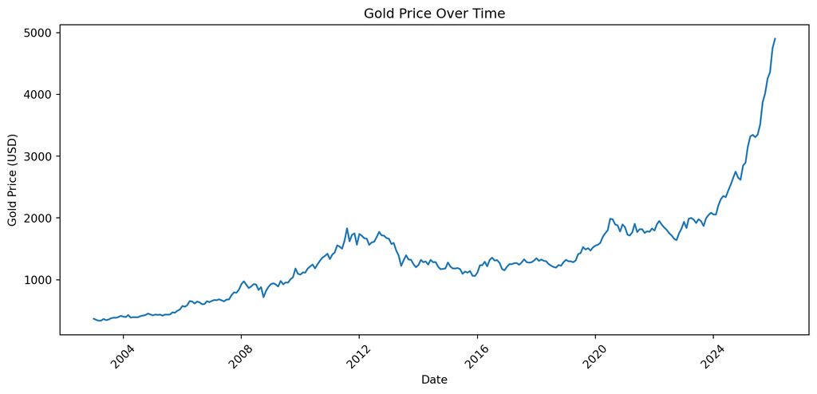

```python
df['date'] = pd.to_datetime(df['date'])
plt.figure(figsize=(12, 5))
plt.plot(df['date'], df['gold_price'])
plt.title('Gold Price Over Time')
plt.xlabel('Date')
plt.ylabel('Gold Price (USD)')
plt.xticks(rotation=45)
plt.show()
```

After the 2008 financial crisis, central banks (especially the US Fed) kept interest rates very low and launched quantitative easing. This led to an increase in gold prices since investor want to hedge potential inflation. In 2020, the COVID-19 pandemic caused a global economic downturn, leading to increased demand for gold as a safe-haven asset, which drove up its price.

### Plotting trend of monthly gold returns

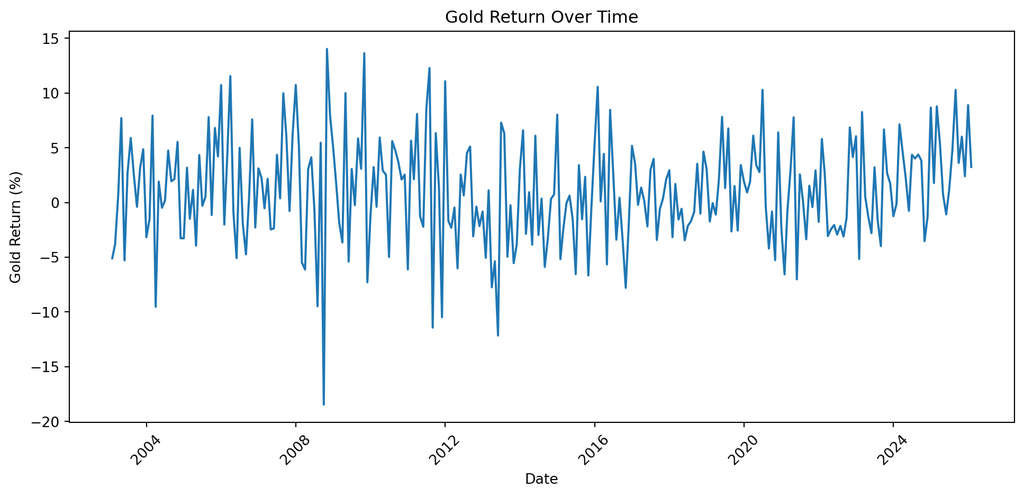

```python
plt.figure(figsize=(12, 5))
plt.plot(df['date'], df['gold_return'])
plt.title('Gold Return Over Time')
plt.xlabel('Date')
plt.ylabel('Gold Return (%)')
plt.xticks(rotation=45)
plt.show()
```

Returns typically range between -10% and +15%, with some extreme values during periods of high volatility (e.g., 2008 financial crisis, 2020 COVID-19 pandemic). In general, volatility seems relatively consistent throughout the sample period, with no clear trend of increasing or decreasing volatility over time. This suggests that the risk associated with gold investments has remained relatively stable over the years.

### Identifying the top 5 months with the highest gold returns

```python
df['abs_return'] = df['gold_return'].abs()
df[['date', 'gold_return', 'abs_return']].nlargest(5, 'abs_return')
```

|  | date | gold_return | abs_return |
| --- | --- | --- | --- |
| 69 | 2008-10-01 | -18.460490 | 18.460490 |
| 70 | 2008-11-01 | 14.035088 | 14.035088 |
| 82 | 2009-11-01 | 13.638985 | 13.638985 |
| 103 | 2011-08-01 | 12.291564 | 12.291564 |
| 125 | 2013-06-01 | -12.153625 | 12.153625 |

We can see that the top 5 months with the highest absolute gold returns are clustered around major economic events, such as the 2008 financial crisis and the 2011 European debt crisis. People sold gold in October 2008 to raise cash to cover margin calls, which led to sharp decline in gold price. Then it bounced back due to it’s safe-heaven propoerty. As a highly liquid assest, gold can experience significant price swings during periods of market stress, as investors rapidly adjust their positions in response to changing economic conditions.

```python
df = df.drop(columns=['abs_return'])
```

### Correlation analysis between gold returns and predictors

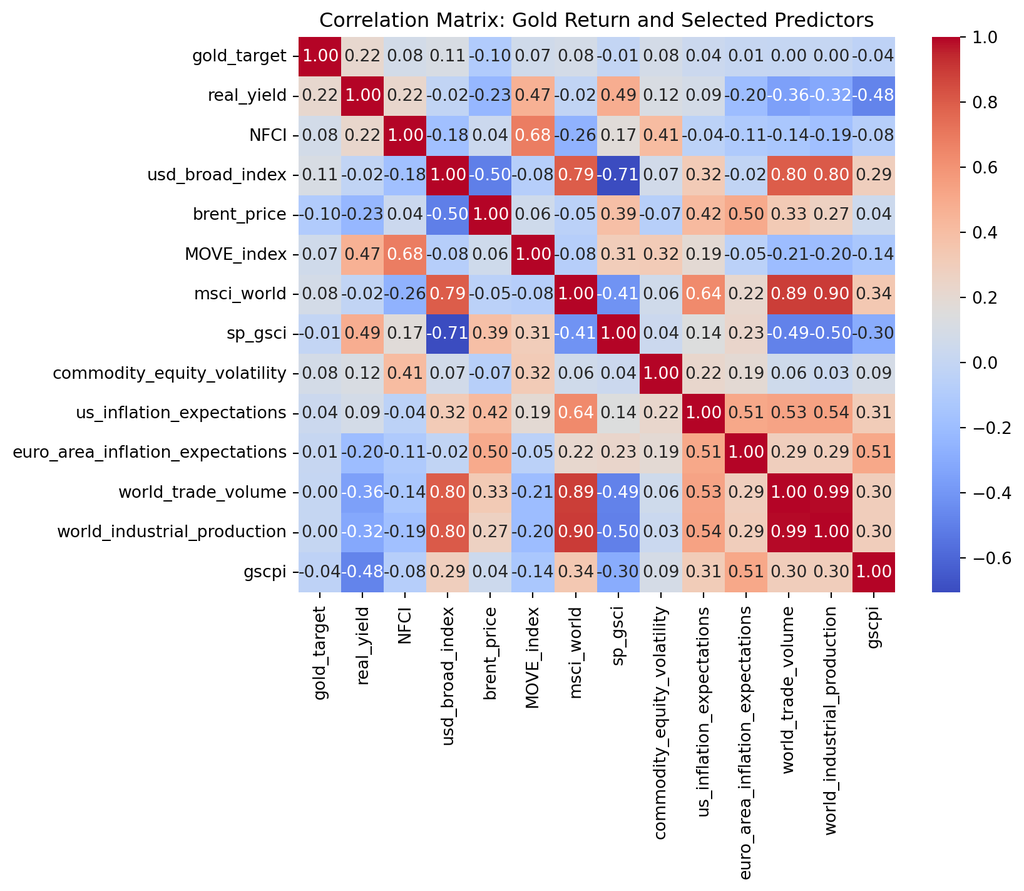

```python
cols = ['gold_target', 'real_yield', 'NFCI', 'usd_broad_index', 'brent_price', 'MOVE_index', 'msci_world','sp_gsci', 'commodity_equity_volatility','us_inflation_expectations', 'euro_area_inflation_expectations', 'world_trade_volume', 'world_industrial_production', 'gscpi']
df[cols].corr()

#Visulisation
corr_matrix = df[cols].corr()

plt.figure(figsize=(8, 6))
sns.heatmap(corr_matrix, annot=True, cmap='coolwarm', fmt='.2f')
plt.title('Correlation Matrix: Gold Return and Selected Predictors')
plt.show()
```

### Multi-variable visualisation

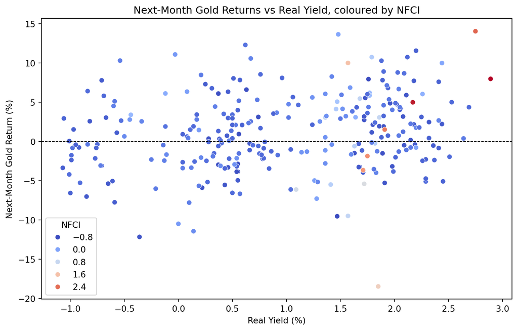

```python
plt.figure(figsize=(10, 6))
sns.scatterplot(data=df,
                x='real_yield',
                y='gold_target',
                hue='NFCI',
                palette='coolwarm')
plt.title('Next-Month Gold Returns vs Real Yield, coloured by NFCI')
plt.xlabel('Real Yield (%)')
plt.ylabel('Next-Month Gold Return (%)')
plt.axhline(0, color='black', linestyle='--', linewidth=0.8)  # zero return line
plt.show()
```

The scatter plot shows a weak positive relationship between real yield and next-month gold returns, which is consistent with the correlation analysis. The color gradient indicates that higher NFCI values (indicating tighter financial conditions) are mixed across the range of real yields, suggesting that NFCI may not have a strong direct relationship with gold returns. However, there may be some interaction effect between real yield and NFCI that could be explored in a regression model. Because we could see the clustering of high NFCI at higher real yields, which may suggest that the effect of real yield on gold returns could be different under different financial conditions. This align the story we concluded in acute 2008 financial stress, gold can go either way depending on whether investors are using it as a safe haven or selling it for liquidity.

## 1.5 Modelling

### 1.5.1 Train/Test Split

```python
#Drop rows with missing values in modelling columns
df['gold_return_lag1'] = df['gold_return'].shift(1) # For later 1.5.3 alternative model
df = df.dropna(subset=['real_yield', 'NFCI', 'usd_broad_index',
                        'gold_target', 'gold_return_lag1'])

# To prevent data leakage, for time series forecasting, the split must always be chronological. Given the dataset runs from 2006 to 2026 (after dropping the early missing rows), we can use the first 80% of the cleaned data for training and the last 20% for testing. It means we will train the model on data from 2006 to around 2021, and test it on data from 2022 to 2026.

train = df[df['date'] < '2022-01']
test = df[df['date'] >= '2022-01']
print(train.shape)
print(test.shape)
print(train['date'].max())  # should be end of 2021
print(test['date'].min())   # should be start of 2022
```

```
(192, 22)
(49, 22)
2021-12-01 00:00:00
2022-01-01 00:00:00
```

### 1.5.2 Baseline Model

#### Feature Selection

The baseline linear regression model is specified as:

$$\hat{r}_{t+1} = \beta_0 + \beta_1 \cdot \text{RealYield}_t + \beta_2 \cdot \text{NFCI}_t + \beta_3 \cdot \text{USD}_t + \epsilon_t$$

Where:

$\hat{r}_{t+1}$ = predicted next-month gold return

$\epsilon_t$ = error term

```python
features = ['real_yield', 'NFCI', 'usd_broad_index']

X_train = train[features]
y_train = train['gold_target']

X_test = test[features]
y_test = test['gold_target']

model = LinearRegression()
model.fit(X_train, y_train)

coefficients = pd.DataFrame({
    'Feature': features,
    'Coefficient': model.coef_
})
print(f'Intercept: {model.intercept_:.4f}')
print(coefficients)

# Model performance evaluation
y_pred = model.predict(X_test)

r2 = r2_score(y_test, y_pred)
rmse = np.sqrt(mean_squared_error(y_test, y_pred))
mae = mean_absolute_error(y_test, y_pred)

print(f'R²: {r2:.4f}')
print(f'RMSE: {rmse:.4f}')
print(f'MAE: {mae:.4f}')
```

```
Intercept: -5.9084
           Feature  Coefficient
0       real_yield     1.082839
1             NFCI     0.446368
2  usd_broad_index     0.059105
R²: 0.0661
RMSE: 3.8394
MAE: 3.3187
```

#### Interpretation

The baseline linear regression model shows that real yield has a positive coefficient ($\beta_1$ = 1.082), suggesting that higher real yields are associated with higher next-month gold returns, which is inconsistent with economic theory. Possible explanations for this could be that the weak correlation between real yield and gold returns in the data may lead to an unstable coefficient estimate, or there may be confounding factors that are not included in the model.

#### Visualize the predicted vs actual gold returns

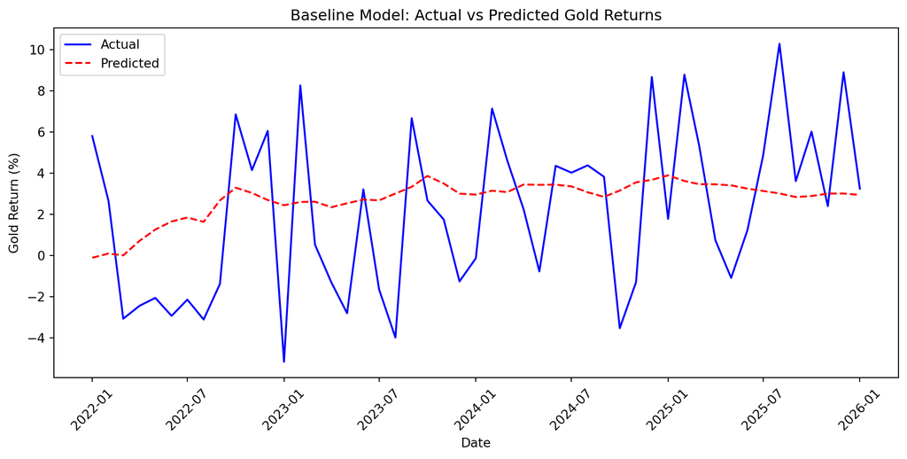

```python
plt.figure(figsize=(12, 5))
plt.plot(test['date'], y_test.values, label='Actual', color='blue')
plt.plot(test['date'], y_pred, label='Predicted', color='red', linestyle='--')
plt.title('Baseline Model: Actual vs Predicted Gold Returns')
plt.xlabel('Date')
plt.ylabel('Gold Return (%)')
plt.legend()
plt.xticks(rotation=45)
plt.show()
```

The predicted line is essentially flat, hovering around 2-4% while the actual returns swing wildly between -5% and +10%. This visually confirms the poor R² — the model can’t capture the volatility of gold returns at all.

### 1.5.3 Alternative Models with lag features

To improve the model, I will add lag features of the target variable (gold returns) to capture the autocorrelation in gold returns.

This is because when forecasting the future values of a gold return, the past values of that same variable are likely to be predictive.

The alternative model is specified as:
$$\hat{r}_{t+1} = \beta_0 + \beta_1 \cdot \text{RealYield}_t + \beta_2 \cdot \text{NFCI}_t + \beta_3 \cdot \text{USD}_t + \beta_4 \cdot r_t + \epsilon_t$$

Where:

$\hat{r}_{t+1}$ = predicted next-month gold return

$r_t$ = current month’s gold return (the lag feature)

$\epsilon_t$ = error term

```python
# Since we have already created the lag feature 'gold_return_lag1' and done the train/test split, we can now directly include it in the feature set for the alternative model.
features_alt = ['real_yield', 'NFCI', 'usd_broad_index', 'gold_return_lag1']

X_train_alt = train[features_alt]
X_test_alt = test[features_alt]

# Fit the alternative model
model_alt = LinearRegression()
model_alt.fit(X_train_alt, y_train)

y_pred_alt = model_alt.predict(X_test_alt)

# Evaluation
coefficients_alt = pd.DataFrame({
    'Feature': features_alt,
    'Coefficient': model_alt.coef_
})
print(f'Intercept: {model.intercept_:.4f}')
print(coefficients_alt)

r2_alt = r2_score(y_test, y_pred_alt)
rmse_alt = np.sqrt(mean_squared_error(y_test, y_pred_alt))
mae_alt = mean_absolute_error(y_test, y_pred_alt)

print(f'R²: {r2_alt:.4f}')
print(f'RMSE: {rmse_alt:.4f}')
print(f'MAE: {mae_alt:.4f}')
```

```
Intercept: -5.9084
            Feature  Coefficient
0        real_yield     1.092056
1              NFCI     0.458687
2   usd_broad_index     0.059017
3  gold_return_lag1    -0.032795
R²: 0.0644
RMSE: 3.8431
MAE: 3.3187
```

## 1.6 Discussion

In terms of modelling strategy, I chose linear regression for baseline and alternative models because the outcome variable is continuous and linear regression provides an interpretable framework to understand the relationship between predictors and gold returns. However, the linear regression model relies on several assumptions that may not hold in this context. For example, the assumption of homoskedasticity may be violated due to the financial crisis and COVID-19 pandemic. Similarly, the train-test split is done chronologically to prevent data leakage, but due to COVID-19 pandemic and the Russia-Ukraine war, the test set is 2022-2026, which may have different dynamics than the training period (2006-2021). This could lead to poor out-of-sample performance. A time-series cross-validation would be more robust.

In future work, I could consider using more sophisticated models (e.g., ARCH or GARCH for volatility, or machine learning models) that can better capture the complex dynamics of gold returns. Incorporating alternative data sources such as central bank gold purchases or news-based sentiment indices — motivated by theories such as the Safe Haven Theory (Baur & Lucey, 2010) — may also improve predictive performance.”

# Part 2: Sovereign Credit Ratings

## 2.1 Load and inspect the data

```python
ratings = pd.read_csv('/Users/leolyu/Desktop/大三/DS202/Summative 1/Raw data/sovereign_ratings_data.csv')
print(ratings.shape)
ratings.head()
ratings.info()
ratings['rating'].unique()
```

```
(1612, 16)
<class 'pandas.core.frame.DataFrame'>
RangeIndex: 1612 entries, 0 to 1611
Data columns (total 16 columns):
 #   Column                   Non-Null Count  Dtype
---  ------                   --------------  -----
 0   year                     1612 non-null   int64
 1   rating                   1612 non-null   object
 2   country_clean            1612 non-null   object
 3   iso3                     1612 non-null   object
 4   country_name             1347 non-null   object
 5   CC.EST                   1347 non-null   float64
 6   GE.EST                   1347 non-null   float64
 7   RQ.EST                   1347 non-null   float64
 8   RL.EST                   1347 non-null   float64
 9   NY.GDP.MKTP.KD.ZG        1347 non-null   float64
 10  BN.CAB.XOKA.GD.ZS        1314 non-null   float64
 11  NE.TRD.GNFS.ZS           1292 non-null   float64
 12  GGSB_NPGDP               1050 non-null   float64
 13  GGXWDG_NGDP              1580 non-null   float64
 14  PCPI                     1593 non-null   float64
 15  REER_IX_RY2010_ACW_RCPI  919 non-null    float64
dtypes: float64(11), int64(1), object(4)
memory usage: 201.6+ KB
```

```
array(['BBB', 'BBB+', 'A-', 'BB-', 'B+', 'B', 'CCC', 'B-', 'CC', 'RD',
       'CCC-', 'BBB-', 'BB', 'BB+', 'AAA', 'AA+', 'AA', 'AA-', 'A+', 'A',
       'CCC+', 'C'], dtype=object)
```

## 2.2 Outcome Construction and Panel Alignment

### 2.2.1 Construct a binary variable is_ig

Only countires with sovereign rating higher than BBB- are classified as investment grade (IG). We use the `isin()` function to check if each rating is in the list of IG ratings, and then convert the resulting boolean values to integers (1 for IG, 0 for non-IG) using `astype(int)`.

```python
ig_ratings = ['AAA', 'AA+', 'AA', 'AA-', 'A+', 'A', 'A-',
              'BBB+', 'BBB', 'BBB-']

ratings['is_ig'] = ratings['rating'].isin(ig_ratings).astype(int)
ratings['is_ig'].value_counts()
```

```
is_ig
1    861
0    751
Name: count, dtype: int64
```

There is 861 IG (1) and 751 non-IG (0) observations which is fairly balanced and suitable for logistic regression modelling.

### 2.2.2 Construct the forecasting target variable

```python
ratings['ig_target'] = ratings.groupby('country_clean')['is_ig'].shift(-1)
ratings = ratings.dropna(subset=['ig_target']) # The last observation per country gets NaN ig_target and is dropped via dropna
ratings[['country_clean', 'year', 'is_ig', 'ig_target']].head(20)
```

|  | country_clean | year | is_ig | ig_target |
| --- | --- | --- | --- | --- |
| 0 | Andorra | 2015 | 1 | 1.0 |
| 1 | Andorra | 2016 | 1 | 1.0 |
| 2 | Andorra | 2017 | 1 | 1.0 |
| 3 | Andorra | 2018 | 1 | 1.0 |
| 4 | Andorra | 2019 | 1 | 1.0 |
| 5 | Andorra | 2020 | 1 | 1.0 |
| 6 | Andorra | 2021 | 1 | 1.0 |
| 7 | Andorra | 2022 | 1 | 1.0 |
| 8 | Andorra | 2023 | 1 | 1.0 |
| 9 | Andorra | 2024 | 1 | 1.0 |
| 11 | Angola | 2012 | 0 | 0.0 |
| 12 | Angola | 2013 | 0 | 0.0 |
| 13 | Angola | 2014 | 0 | 0.0 |
| 14 | Angola | 2015 | 0 | 0.0 |
| 15 | Angola | 2016 | 0 | 0.0 |
| 16 | Angola | 2017 | 0 | 0.0 |
| 17 | Angola | 2018 | 0 | 0.0 |
| 18 | Angola | 2019 | 0 | 0.0 |
| 19 | Angola | 2020 | 0 | 0.0 |
| 20 | Angola | 2021 | 0 | 0.0 |

### 2.2.3 Data handling

We need to check there are no non-consecutive years for any country, which would produce a NaN target variable for the next year. We can check this by calculating the year difference between consecutive rows for each country.

```python
# Check the year gap for each country
ratings['year_diff'] = ratings.groupby('country_clean')['year'].diff()
ratings['year_diff'].value_counts()
print(f" There are {ratings['country_clean'].nunique()} unique countries in the dataset.")
print(ratings.shape)
```

```
 There are 125 unique countries in the dataset.
(1487, 19)
```

```python
# Check for any remaining missing values after dropna
print("The missing values in each columns")
print(ratings.isnull().sum())
```

```
The missing values in each columns
year                         0
rating                       0
country_clean                0
iso3                         0
country_name               140
CC.EST                     140
GE.EST                     140
RQ.EST                     140
RL.EST                     140
NY.GDP.MKTP.KD.ZG          140
BN.CAB.XOKA.GD.ZS          173
NE.TRD.GNFS.ZS             195
GGSB_NPGDP                 511
GGXWDG_NGDP                 25
PCPI                        16
REER_IX_RY2010_ACW_RCPI    635
is_ig                        0
ig_target                    0
year_diff                  125
dtype: int64
```

This confirms that there are:

- 125 countries in the dataset
- 1487 rows after dropna
- 1362 consecutive pairs = 1487 rows - 125 countries (first year of each country has no previous year)

## 2.3 Data Exploration

### 2.3.1 Examine the distribution of Fitch ratings

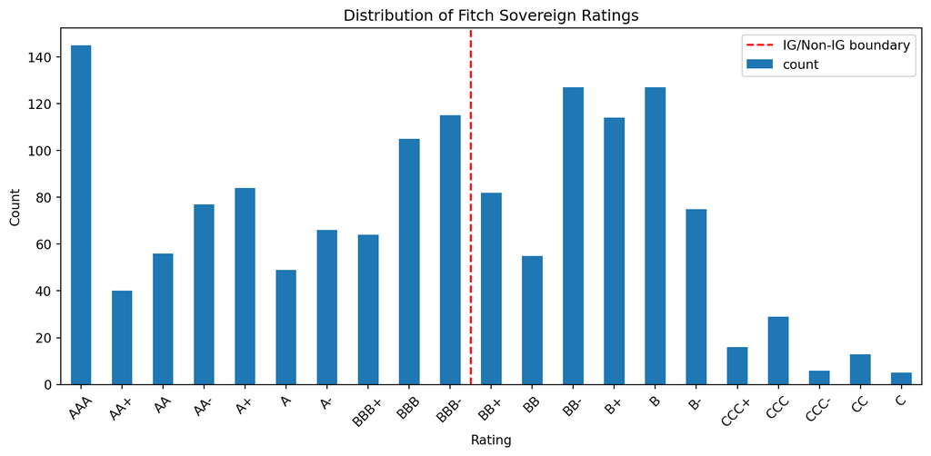

```python
rating_order = ['AAA', 'AA+', 'AA', 'AA-', 'A+', 'A', 'A-',
                'BBB+', 'BBB', 'BBB-', 'BB+', 'BB', 'BB-',
                'B+', 'B', 'B-', 'CCC+', 'CCC', 'CCC-', 'CC', 'C']

rating_counts = ratings['rating'].value_counts().reindex(rating_order)

plt.figure(figsize=(12, 5))
rating_counts.plot(kind='bar')
plt.title('Distribution of Fitch Sovereign Ratings')
plt.xlabel('Rating')
plt.ylabel('Count')
plt.xticks(rotation=45)
plt.axvline(x=9.5, color='red', linestyle='--', label='IG/Non-IG boundary')
plt.legend()
plt.show()
```

We can observe that ratings are broadly distributed across the scale, though there is a notable concentration at AAA, suggesting several highly-rated countries have maintained top-tier status consistently throughout the sample period. On the non-investment grade side, ratings cluster around B and B+, with very few observations at the extreme lower end (CCC, CC, C).

### 2.3.2 Identify rating switches over time

To identify rating switches, we can convert the categorical ratings into a numerical scale where higher numbers correspond to better ratings. Then we can calculate the year-to-year change in ratings for each country to see if there are any upgrades or downgrades.

```python
rating_map = {
    'AAA': 21, 'AA+': 20, 'AA': 19, 'AA-': 18,
    'A+': 17, 'A': 16, 'A-': 15,
    'BBB+': 14, 'BBB': 13, 'BBB-': 12,
    'BB+': 11, 'BB': 10, 'BB-': 9,
    'B+': 8, 'B': 7, 'B-': 6,
    'CCC+': 5, 'CCC': 4, 'CCC-': 3,
    'CC': 2, 'C': 1}

ratings['rating_numeric'] = ratings['rating'].map(rating_map)

# Count the frequency of year-to-year change in ratings for all countires

ratings['rating_change'] = ratings.groupby('country_clean')['rating_numeric'].diff()

print(ratings['rating_change'].value_counts().head(10))
print(f"Upgrades: {(ratings['rating_change'] > 0).sum()}")
print(f"Downgrades: {(ratings['rating_change'] < 0).sum()}")
print(f"No change: {(ratings['rating_change'] == 0).sum()}")
```

```
rating_change
 0.0    1039
-1.0     120
 1.0     105
-2.0      20
 2.0      18
-3.0       7
-4.0       6
-5.0       3
 3.0       2
-6.0       1
Name: count, dtype: int64
Upgrades: 125
Downgrades: 158
No change: 1039
```

Overall, rating changes occur in approximately 21% of country-year transitions, suggesting that sovereign ratings are relatively sticky. Most countries maintain the same rating from one year to the next. For the changes that do occur, there are more downgrades (158) than upgrades (125), suggesting that sovereign credit ratings are more likely to deteriorate than improve over time, which is consistent with the notion of rating agencies being more cautious in upgrading than downgrading. The most common magnitude of change is 1-notch (either +1 or -1), but some larger changes do occur, with a few instances of 2-notch and 3-notch changes and even a -6 notch change.

### 2.3.3 Rating changes and IG status

Only changes that cross the BBB-/BB+ boundary result in a change in IG status. To check this, we can look at rows where rating_change not equl to 0 and their is_ig stays the same.

```python
ratings['ig_change'] = ratings.groupby('country_clean')['is_ig'].diff()

# Changes in rating and changes take place NOT in IG status
within_category = ratings[
    (ratings['rating_change'] != 0) &
    (ratings['ig_change'] == 0) &
    (ratings['rating_change'].notna())]

# Changes that Do affect IG status
boundary_crosses = ratings[
    (ratings['ig_change'] != 0) &
    (ratings['ig_change'].notna())]

print(f'Rating changes within same IG category: {len(within_category)}')
print(f'Rating changes crossing IG boundary: {len(boundary_crosses)}')
```

```
Rating changes within same IG category: 261
Rating changes crossing IG boundary: 22
```

```python
# Example of boundary crossing
boundary_crosses = ratings[
    (ratings['ig_change'] == 1) | (ratings['ig_change'] == -1)
][['country_clean', 'year', 'rating', 'is_ig', 'ig_change']].head(10)

display(boundary_crosses)

# Example of within-category changes with alphabetic order
display(within_category[['country_clean', 'year', 'rating', 'is_ig', 'rating_change']].head(10))
```

|  | country_clean | year | rating | is_ig | ig_change |
| --- | --- | --- | --- | --- | --- |
| 61 | Aruba | 2020 | BB | 0 | -1.0 |
| 99 | Azerbaijan | 2016 | BB+ | 0 | -1.0 |
| 107 | Azerbaijan | 2024 | BBB- | 1 | 1.0 |
| 113 | Bahrain | 2016 | BB+ | 0 | -1.0 |
| 201 | Brazil | 2015 | BB+ | 0 | -1.0 |
| 307 | Colombia | 2021 | BB+ | 0 | -1.0 |
| 340 | Croatia | 2013 | BB+ | 0 | -1.0 |
| 346 | Croatia | 2019 | BBB- | 1 | 1.0 |
| 359 | Cyprus | 2018 | BBB- | 1 | 1.0 |
| 572 | Greece | 2023 | BBB- | 1 | 1.0 |

|  | country_clean | year | rating | is_ig | rating_change |
| --- | --- | --- | --- | --- | --- |
| 3 | Andorra | 2018 | BBB+ | 1 | 1.0 |
| 7 | Andorra | 2022 | A- | 1 | 1.0 |
| 14 | Angola | 2015 | B+ | 0 | -1.0 |
| 15 | Angola | 2016 | B | 0 | -1.0 |
| 19 | Angola | 2020 | CCC | 0 | -3.0 |
| 21 | Angola | 2022 | B- | 0 | 2.0 |
| 32 | Argentina | 2019 | CC | 0 | -5.0 |
| 33 | Argentina | 2020 | CCC | 0 | 2.0 |
| 35 | Argentina | 2022 | CCC- | 0 | -1.0 |
| 36 | Argentina | 2023 | CC | 0 | -1.0 |

You can see that the majority of rating changes (261/283 = 92.2%) occur within the same IG category, meaning they do not affect the investment grade status. Only about 8% of rating changes result in a change in IG status, examples include Azerbaijan (2024) upgraded from BB+ to BBB-, and Bahrain (2016) downgraded from BBB- to BB+. This suggests that while ratings may fluctuate, they often do so without crossing the critical threshold that defines investment grade. This highlights the relative stability of sovereign credit ratings.

```python
# Select 6 macroeconomic indicators for comparison
indicators = ['CC.EST', 'NY.GDP.MKTP.KD.ZG', 'BN.CAB.XOKA.GD.ZS', 'NE.TRD.GNFS.ZS', 'GGXWDG_NGDP', 'PCPI']

ratings.groupby('is_ig')[indicators].mean().round(2)
```

| is_ig | CC.EST | NY.GDP.MKTP.KD.ZG | BN.CAB.XOKA.GD.ZS | NE.TRD.GNFS.ZS | GGXWDG_NGDP | PCPI |
| --- | --- | --- | --- | --- | --- | --- |
| 0 | -0.42 | 2.68 | -3.83 | 81.36 | 67.30 | 5.332425e+11 |
| 1 | 0.78 | 2.63 | 2.35 | 110.38 | 58.12 | 9.353573e+10 |

```python
ratings.groupby('is_ig')[indicators].median().round(2)
```

| is_ig | CC.EST | NY.GDP.MKTP.KD.ZG | BN.CAB.XOKA.GD.ZS | NE.TRD.GNFS.ZS | GGXWDG_NGDP | PCPI |
| --- | --- | --- | --- | --- | --- | --- |
| 0 | -0.48 | 3.42 | -2.94 | 73.84 | 58.99 | 111.38 |
| 1 | 0.78 | 2.64 | 0.94 | 84.86 | 49.65 | 103.48 |

- Inflation (PCPI) median is much more reasonable for both IG (103.48) and non-IG countires (111.38)

### 2.3.5 Visualise the distribution of control of corruption (CC.EST) and Current account balance (BN.CAB.XOKA.GD.ZS) for IG vs non-IG countries

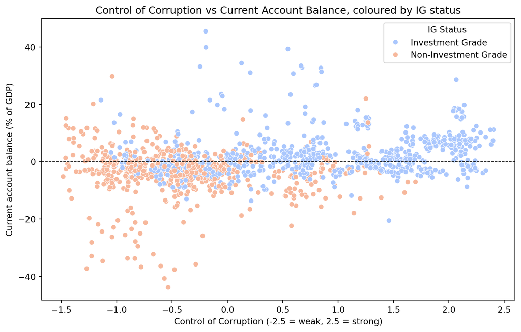

```python
ratings['IG Status'] = ratings['is_ig'].map({1: 'Investment Grade', 0: 'Non-Investment Grade'})

plt.figure(figsize=(10, 6))
sns.scatterplot(data=ratings,
                x='CC.EST',
                y='BN.CAB.XOKA.GD.ZS',
                hue='IG Status',
                palette='coolwarm')
plt.title('Control of Corruption vs Current Account Balance, coloured by IG status')
plt.xlabel('Control of Corruption (-2.5 = weak, 2.5 = strong)')
plt.ylabel('Current account balance (% of GDP)')
plt.axhline(0, color='black', linestyle='--', linewidth=0.8)
plt.show()
```

#### Interpretation:

From the scatter plot, we can see that Investment Grade countries (in blue) tend to cluster towards higher values of Control of Corruption and more positive Current Account Balances, while Non-Investment Grade countries (in orange) are more spread out but generally have lower Control of Corruption values and more negative current account balances. This is because better governance and lower corruption can lead to more stable economic policies and stronger institutions, which in turn can improve a country’s creditworthiness. Additionally, countries with positive current account balances may be seen as more financially stable and less reliant on external financing, which can also contribute to higher credit ratings. However, there is considerable overlap between the two groups in the middle of the chart, suggesting that no single indicator is sufficient to fully separate IG from non-IG countries — a multivariate modelling approach is therefore warranted.

#### Feature selection for modelling should be based on both theoretical relevance and empirical discrimination power:

Among all the features, Control of Corruption appears to be a particularly strong discriminator between IG and non-IG countries. Higher control of corruption indicates better governance quality, meaning more investors would likely view these markets as stable environments for capital allocation. Trade openness is also an important factor to consider in the modeling stage, given its significant variance between IG and non-IG countries and its theoretical relevance to creditworthiness. Finally, we can also see some outliers with very negative current account balances (e.g., around -40% of GDP), which may be worth investigating further as they could represent countries with significant financial vulnerabilities. Under these 3 predictors, we get a good balance from one governance indicator (CC.EST), one economic performance indicator (current account balance) and one global integration indicator (trade openness), which also naturally reduce the risk of multicollinearity in the model.

## 2.4 Modelling

### 2.4.1 Missing data handling, feature scaling and train-test split

#### Check if missingness is clustered at start or random

Before train/test split, we need to check the missing data pattern for the three features (CC.EST, NE.TRD.GNFS.ZS, BN.CAB.XOKA.GD.ZS) to determine how to handle them. If the missingness is clustered at the start of the sample, it may be due to data availability issues and we can consider dropping those early rows. If the missingness is random, we may need to impute the missing values using methods such as mean imputation or regression imputation.

```python
# Missingness in Control of Corruption (CC.EST)
ratings[ratings['CC.EST'].isna()]['year'].value_counts().sort_index()
```

```
year
2012      2
2013      2
2014      2
2015      1
2016      1
2017      1
2018      1
2019      1
2020      1
2021      1
2022      1
2023      1
2024    125
Name: count, dtype: int64
```

```python
# Missingness in Trade openness (NE.TRD.GNFS.ZS)
ratings[ratings['NE.TRD.GNFS.ZS'].isna()]['year'].value_counts().sort_index()
```

```
year
2012      6
2013      6
2014      6
2015      5
2016      5
2017      5
2018      5
2019      5
2020      6
2021      6
2022      7
2023      8
2024    125
Name: count, dtype: int64
```

```python
# Missingness in Current account balance (BN.CAB.XOKA.GD.ZS)
ratings[ratings['BN.CAB.XOKA.GD.ZS'].isna()]['year'].value_counts().sort_index()
```

```
year
2012      2
2013      2
2014      2
2015      3
2016      4
2017      5
2018      5
2019      3
2020      4
2021      5
2022      7
2023      6
2024    125
Name: count, dtype: int64
```

Missing values are concentrated in 2024 (125 out of 140 for CC.EST, 125/173 for current account balance, 125/195 for trade openness), likely due to delayed data release from the World Bank. As this constitutes MNAR missingness, 2024 rows are dropped entirely. Remaining missing values (2012–2023) are small in number and imputed with the column mean for simplicity, as they are likely MAR missingness due to random reporting issues. Imputation will be done after train-test split to prevent data leakage.

```python
# Drop 2024 data
ratings = ratings[ratings['year'] != 2024]

# Recheck the year distribution after dropping 2024
ratings.groupby('year').size()
```

```
year
2012    101
2013    104
2014    106
2015    111
2016    112
2017    114
2018    115
2019    117
2020    119
2021    120
2022    121
2023    122
dtype: int64
```

A time-based split is appropriate for this panel data to prevent data leakage. We will use the first 80% of the time period for training and the last 20% for testing. To determine the cutoff year, we can check the minimum and maximum years in the dataset.

```python
print(ratings['year'].min())
print(ratings['year'].max())
```

```
2012
2023
```

The dataset covers the period from 2012 to 2023, which covers 12 years, the 80% of 12 years is around 10 years, so 2012 + 10 = 2022 as the cutoff line for train-test split. We will train the model on data from 2012 to 2021, and test it on data from 2022 to 2023.

```python
# Split full dataframe
train_p2 = ratings[ratings['year'] < 2022]
test_p2 = ratings[ratings['year'] >= 2022]

# Define features and target
features_p2 = ['CC.EST', 'NE.TRD.GNFS.ZS', 'BN.CAB.XOKA.GD.ZS']

# Part 2 specific names
X_train_p2 = train_p2[features_p2]
y_train_p2 = train_p2['ig_target']
X_test_p2 = test_p2[features_p2]
y_test_p2 = test_p2['ig_target']

# Impute
from sklearn.impute import SimpleImputer
imputer_p2 = SimpleImputer(strategy='mean')
X_train_p2 = imputer_p2.fit_transform(X_train_p2)
X_test_p2 = imputer_p2.transform(X_test_p2)
```

Before fitting the logistic regression model, we will scale the features using StandardScaler to ensure that they are on the same scale. The three features we use have different units and ranges:

- CC.EST ranges from -1.5 to 2.5
- NE.TRD.GNFS.ZS ranges from ~50 to 200+
- BN.CAB.XOKA.GD.ZS ranges from -40 to +45

Without scaling, the logistic regression solver (gradient descent) takes much longer to converge because features with larger scales dominate the optimization. Scaling puts all features on equal footing with mean=0, std=1.

```python
# Scale
scaler_p2 = StandardScaler()
X_train_p2_scaled = scaler_p2.fit_transform(X_train_p2)
X_test_p2_scaled = scaler_p2.transform(X_test_p2)

# Verify no missing values remain in imputed data
print("Missing values in training set:", np.isnan(X_train_p2).sum())
print("Missing values in test set:", np.isnan(X_test_p2).sum())
```

```
Missing values in training set: 0
Missing values in test set: 0
```

### 2.4.2 Baseline Model: Logistic Regression

Logistic regression is an appropriate choice for the baseline model because the outcome variable (ig_target) is binary, indicating whether a country will be investment grade (1) or non-investment grade (0) in the next year. Logistic regression starts exactly as linear regression with a linear combination of the predictors, but then applies a sigmoid function to convert the output into a probability between 0 and 1. Finally, a decision rule is applied to classify the outcome based on a threshold (commonly 0.5). The mathematical formulation of logistic regression can be expressed as follows:

#### Mathematical formulation of logistic regression:

**Step 1 — Linear combination:**

$$z = \beta_0 + \beta_1 \cdot \text{CC.EST} + \beta_2 \cdot \text{TradeOpenness} + \beta_3 \cdot \text{CurrentAccount}$$

**Step 2 — Sigmoid function:**

$$P(ig\_target_{t+1} = 1) = \frac{1}{1 + e^{-z}}$$

**Step 3 — Decision rule:**

$$\hat{y} = \begin{cases} 1 & \text{if } P \geq 0.5 \\ 0 & \text{if } P < 0.5 \end{cases}$$

#### Fit logistic regression model using statsmodels

```python
# Add constant (intercept) term for statsmodels
X_train_sm = sm.add_constant(X_train_p2_scaled)
X_test_sm = sm.add_constant(X_test_p2_scaled)

# Fit logistic regression
logit_model = sm.Logit(y_train_p2, X_train_sm).fit()

# Print summary
print(logit_model.summary())
```

```
Optimization terminated successfully.
         Current function value: 0.415282
         Iterations 7
                           Logit Regression Results
==============================================================================
Dep. Variable:              ig_target   No. Observations:                 1119
Model:                          Logit   Df Residuals:                     1115
Method:                           MLE   Df Model:                            3
Date:                Tue, 10 Mar 2026   Pseudo R-squ.:                  0.3966
Time:                        18:23:47   Log-Likelihood:                -464.70
converged:                       True   LL-Null:                       -770.12
Covariance Type:            nonrobust   LLR p-value:                4.519e-132
==============================================================================
                 coef    std err          z      P>|z|      [0.025      0.975]
------------------------------------------------------------------------------
const          0.5685      0.092      6.198      0.000       0.389       0.748
x1             1.8806      0.135     13.892      0.000       1.615       2.146
x2            -0.2228      0.117     -1.905      0.057      -0.452       0.006
x3             1.3873      0.139     10.009      0.000       1.116       1.659
==============================================================================
```

#### Evaluation of model performance

```
Accuracy: 0.7613
ROC-AUC: 0.8410
[[91 32]
 [26 94]]
```

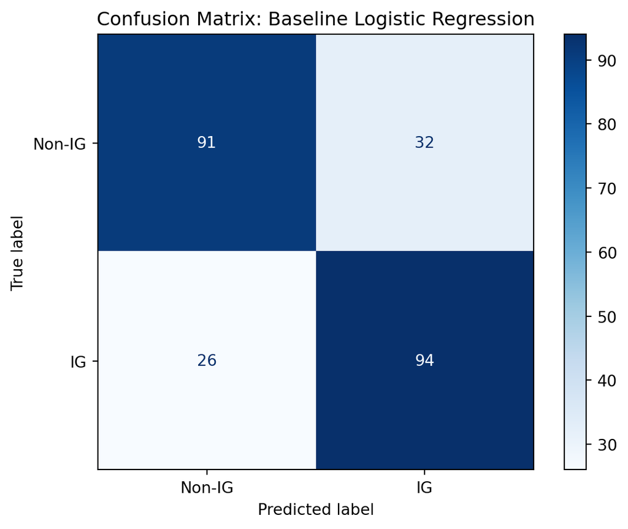

```
              precision    recall  f1-score   support

         0.0       0.78      0.74      0.76       123
         1.0       0.75      0.78      0.76       120

    accuracy                           0.76       243
   macro avg       0.76      0.76      0.76       243
weighted avg       0.76      0.76      0.76       243
```

```python
from sklearn.metrics import accuracy_score, confusion_matrix, roc_auc_score, classification_report, ConfusionMatrixDisplay

# Get predictions
y_pred = logit_model.predict(X_test_sm) > 0.5

print(f'Accuracy: {accuracy_score(y_test_p2, y_pred):.4f}')
print(f'ROC-AUC: {roc_auc_score(y_test_p2, logit_model.predict(X_test_sm)):.4f}')
print(confusion_matrix(y_test_p2, y_pred))
# Visualize confusion matrix
cm = confusion_matrix(y_test_p2, y_pred)
disp = ConfusionMatrixDisplay(confusion_matrix=cm,
                               display_labels=['Non-IG', 'IG'])
disp.plot(cmap='Blues')
plt.title('Confusion Matrix: Baseline Logistic Regression')
plt.show()

print(classification_report(y_test_p2, y_pred))
```

The logistic model I build could achieve an accuracy of 0.76, which means it correctly classifies 76% of the test observations as IG or non-IG. The ROC-AUC of 0.84 indicates good discriminative ability, it means there is an 84% probability that the model will rank a randomly chosen IG country higher (more likely to be IG) than a randomly chosen non-IG country. In the context of sovereign credit ratings, false positives (incorrectly classifying non-IG countries as IG) are particularly costly, as investors may inadvertently hold higher-risk assets than intended. The model produces 32 false positives compared to 26 false negatives, suggesting a slight tendency to overrate countries.

Since the F1-score is the harmonic mean of Precision and Recall, it provides a balance between the two metrics. The F1-score for IG class is 0.76, which indicates a good balance between precision (0.75) and recall (0.78). For the non-IG class, the F1-score is the same (0.76) but with a higher precision (0.78) and lower recall (0.74), suggesting that the model perform more or less equally well for both classes.

#### Precision-Recall curve and threshold table

|  | Threshold | Precision | Recall |
| --- | --- | --- | --- |
| 0 | 0.1 | 0.541 | 1.000 |
| 1 | 0.2 | 0.595 | 0.942 |
| 2 | 0.3 | 0.654 | 0.883 |
| 3 | 0.4 | 0.690 | 0.817 |
| 4 | 0.5 | 0.746 | 0.783 |
| 5 | 0.6 | 0.795 | 0.742 |
| 6 | 0.7 | 0.816 | 0.667 |
| 7 | 0.8 | 0.849 | 0.608 |

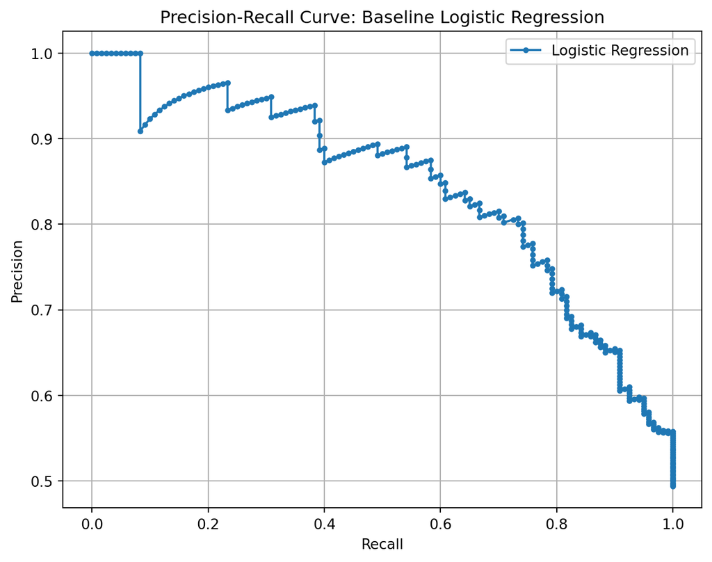

```python
from sklearn.metrics import precision_recall_curve, PrecisionRecallDisplay

# Get predicted probabilities
y_pred_proba = logit_model.predict(X_test_sm)

# Precision-Recall curve
precision, recall, thresholds = precision_recall_curve(y_test_p2, y_pred_proba)

# The threshold table
th_list = np.arange(0.1, 0.9, 0.1)
results = []
for th in th_list:
    y_pred_th = (y_pred_proba > th).astype(int)
    from sklearn.metrics import precision_score, recall_score
    results.append({
        'Threshold': round(th, 1),
        'Precision': round(precision_score(y_test_p2, y_pred_th), 3),
        'Recall': round(recall_score(y_test_p2, y_pred_th), 3)
    })
display(pd.DataFrame(results))

# Plot
plt.figure(figsize=(8, 6))
plt.plot(recall, precision, marker='.', label='Logistic Regression')
plt.xlabel('Recall')
plt.ylabel('Precision')
plt.title('Precision-Recall Curve: Baseline Logistic Regression')
plt.legend()
plt.grid(True)
plt.show()
```

Given that false positives carry greater economic risk in credit rating contexts, as investors may inadvertently hold speculative-grade assets, a higher threshold of 0.6 ~ 0.7 may be preferable despite the reduction in recall. At threshold 0.6, precision rises to 0.8 while recall remains acceptable at 0.74, providing a better balance for practical applications.Ultimately, the choice of threshold should be guided by the specific risk tolerance and investment objectives of the stakeholders using the model.

### 2.4.3 Alternative model: L1 (Lasso) Regularization Logistic Regression

$$\min_{\beta} \left[ -\frac{1}{n}\sum_{i=1}^{n} \left[ y_i \log(p_i) + (1-y_i)\log(1-p_i) \right] + \lambda \sum_{j=1}^{p} |\beta_j| \right]$$

Where:

- $y_i$ is the true label (0 or 1)
- $p_i = \sigma(\beta_0 + \beta_1 x_{i1} + \cdots + \beta_p x_{ip})$ is the predicted probability
- $\lambda$ is the regularisation strength — higher values shrink more coefficients to zero
- $\sum_{j=1}^{p} |\beta_j|$ is the L1 penalty term

This L1 term ($\lambda \sum_{j=1}^{p} |\beta_j|$) would penalise larger coefficients, effectively performing feature selection by shrinking some coefficients to zero, thus identifying the most important predictors of IG status while reducing the risk of overfitting.

#### Why not Random Forest or SVM?

While Random Forest and SVM may achieve higher predictive accuracy, they produce poorly calibrated probabilities and require additional calibration procedures (e.g. Platt scaling). In contrast, logistic regression directly models probabilities via Maximum Likelihood Estimation (MLE), making it naturally well-calibrated and more suitable for contexts where probability estimates are important — such as credit rating where investors need reliable probability estimates of IG status. Moreover, logistic regression provides interpretable coefficients that can be directly linked to the odds of being IG, which is valuable for understanding the drivers of creditworthiness. Random Forest and SVM, while powerful, are often considered “black box” models that lack this level of interpretability without additional tools (e.g., SHAP values), which may not be as straightforward for stakeholders in the credit rating industry.

#### Preprocessing for lasso logistic regression

```python
# Data cleaning
all_features = ['CC.EST', 'GE.EST', 'RQ.EST', 'RL.EST',
                'NY.GDP.MKTP.KD.ZG', 'BN.CAB.XOKA.GD.ZS',
                'NE.TRD.GNFS.ZS', 'GGXWDG_NGDP', 'PCPI']

ratings[all_features].isnull().sum()

# Split
X_train_lasso = train_p2[all_features]
X_test_lasso = test_p2[all_features]

# Impute missing values with mean
imputer_lasso = SimpleImputer(strategy='mean')
X_train_lasso = imputer_lasso.fit_transform(X_train_lasso) # Fit on train, transform on train
X_test_lasso = imputer_lasso.transform(X_test_lasso) # Only transform on test to prevent data leakage

# Scale
scaler_lasso = StandardScaler()
X_train_lasso_scaled = scaler_lasso.fit_transform(X_train_lasso)
X_test_lasso_scaled = scaler_lasso.transform(X_test_lasso)
```

#### Fit the lasso logistic regression model

Unlike the baseline model fitted using statsmodels, the Lasso model is fitted using scikit-learn’s LogisticRegression with penalty=‘l1’, as statsmodels does not natively support L1 regularisation. This means p-values and confidence intervals are not available for the Lasso model — the focus is instead on coefficient magnitude and feature selection.

```python
lasso_model = LogisticRegression(l1_ratio = 1,
                                  solver='liblinear',
                                  C=1.0,
                                  random_state=42,
                                  max_iter=1000)
lasso_model.fit(X_train_lasso_scaled, y_train_p2)

# Show coefficients
coef_df = pd.DataFrame({
    'Feature': all_features,
    'Coefficient': lasso_model.coef_[0]
})
display(coef_df)
```

|  | Feature | Coefficient |
| --- | --- | --- |
| 0 | CC.EST | -2.419982 |
| 1 | GE.EST | 3.270092 |
| 2 | RQ.EST | 2.670191 |
| 3 | RL.EST | 1.203945 |
| 4 | NY.GDP.MKTP.KD.ZG | 0.195804 |
| 5 | BN.CAB.XOKA.GD.ZS | 1.366770 |
| 6 | NE.TRD.GNFS.ZS | -1.454323 |
| 7 | GGXWDG_NGDP | -1.438064 |
| 8 | PCPI | 0.000000 |

```python
# Cross-validation with different C values
for C in [0.1, 0.5, 1.0, 2.0]:
    model = LogisticRegression(l1_ratio = 1, solver='liblinear',
                                C=C, random_state=42)
    model.fit(X_train_lasso_scaled, y_train_p2)
    print(f'\nC={C}:')
    for feat, coef in zip(all_features, model.coef_[0]):
        print(f'{feat}: {coef:.3f}')
```

```
C=0.1:
CC.EST: -0.146
GE.EST: 1.483
RQ.EST: 1.899
RL.EST: 0.000
NY.GDP.MKTP.KD.ZG: 0.031
BN.CAB.XOKA.GD.ZS: 1.030
NE.TRD.GNFS.ZS: -0.667
GGXWDG_NGDP: -0.895
PCPI: 0.000

C=0.5:
CC.EST: -1.935
GE.EST: 3.002
RQ.EST: 2.543
RL.EST: 0.782
NY.GDP.MKTP.KD.ZG: 0.169
BN.CAB.XOKA.GD.ZS: 1.299
NE.TRD.GNFS.ZS: -1.287
GGXWDG_NGDP: -1.317
PCPI: 0.000

C=1.0:
CC.EST: -2.420
GE.EST: 3.270
RQ.EST: 2.670
RL.EST: 1.204
NY.GDP.MKTP.KD.ZG: 0.196
BN.CAB.XOKA.GD.ZS: 1.367
NE.TRD.GNFS.ZS: -1.454
GGXWDG_NGDP: -1.438
PCPI: 0.000

C=2.0:
CC.EST: -2.696
GE.EST: 3.426
RQ.EST: 2.750
RL.EST: 1.444
NY.GDP.MKTP.KD.ZG: 0.211
BN.CAB.XOKA.GD.ZS: 1.407
NE.TRD.GNFS.ZS: -1.552
GGXWDG_NGDP: -1.510
PCPI: 0.000
```

Since scikit-learn’s Lasso implementation does not provide p-values or confidence intervals, we assess coefficient stability by varying the regularisation strength C across [0.1, 0.5, 1.0, 2.0]. C = 1/λ, so smaller C (0.1) means stronger regularisation — features that survive (remain non-zero) under strong regularisation are more robustly important predictors. This serves as an informal substitute for significance testing.”

#### Interpretation of lasso coefficients

We can see that surprisingly, the coefficient for Control of Corruption (CC.EST) is very large and negative (-2.42), which is contrary to the finding in baseline. This is due to multicollinearity among the governance indicators, CC.EST, Government Effectiveness (GE.EST), Regulatory Quality (RQ.EST) and Rule of Law (RL.EST), which are all highly correlated and measure similar aspects of governance quality. The correlation matrix heatmap confirmed this:

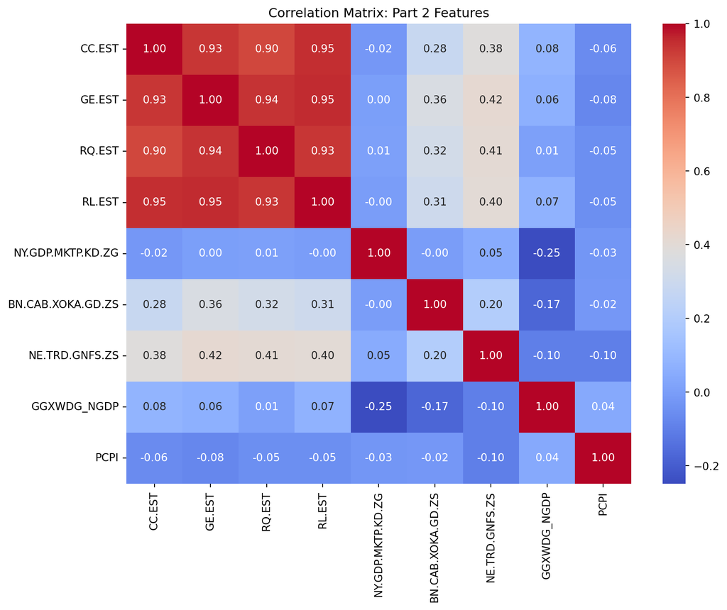

```python
# Correlation matrix for all Part 2 features
plt.figure(figsize=(10, 8))
sns.heatmap(ratings[all_features].corr(),
            annot=True,
            cmap='coolwarm',
            fmt='.2f')
plt.title('Correlation Matrix: Part 2 Features')
plt.tight_layout()
plt.show()
```

- CC.EST ↔︎ GE.EST: 0.93
- CC.EST ↔︎ RQ.EST: 0.90
- CC.EST ↔︎ RL.EST: 0.95
- GE.EST ↔︎ RL.EST: 0.95

As a result of this multicollinearity, when Lasso tries to distribute the effect across these correlated features, it can produce unexpected sign flips and large coefficient magnitudes as it arbitrarily assigns importance to one feature over the others.

To assess coefficient stability in the absence of p-values, we vary $C$ across $[0.1, 0.5, 1.0, 2.0]$, identifying Government Effectiveness, Regulatory Quality, and key macroeconomic indicators as robustly important due to their persistence at all regularization levels. In contrast, inflation (PCPI) is definitively unimportant, as it is eliminated by the L1 penalty regardless of the $C$ value, while Rule of Law (RL.EST) appears only moderately important since it drops to zero under the strictest penalty ($C=0.1$). Finally, GDP growth is categorized as weakly important, maintaining a negligible coefficient magnitude across the entire range of $C$ values, suggesting it lacks the discriminatory power of structural fiscal and governance levels.

For specific macroeconomic indicators analysis:

- The coefficients for current account balance remain positive and significant across all C-value, suggesting it is a robust predictors of IG, consistent with baseline model.
- General Government Debt remain negative and significant across all C-value. This means that higher debt-to-GDP are associated with lower likelihood of being IG, because it could exponentially increase the perceived risk of default. This is the “fiscal ceiling” that often keeps emerging markets in the non-IG category.
- Trade openness has a negative coefficient across all C-value, suggesting that more open economies are less likely to be IG. This often suggests “External Vulnerability.” Countries that are too open may be overly sensitive to global commodity price crashes or supply chain disruptions, which creates the economic volatility that rating agencies dislike. Those results reinforce the idea that economic performance and global integration are important factors in sovereign credit ratings.

Additionally, the large coefficient magnitudes suggest potential near-perfect separation, where governance indicators almost perfectly distinguish IG from non-IG countries. This is precisely why Lasso regularisation is valuable — the L1 penalty prevents coefficients from growing toward ±∞, stabilising the estimation.

#### Evaluation of lasso model performance

```
Accuracy: 0.8683
ROC-AUC: 0.9369
              precision    recall  f1-score   support

         0.0       0.86      0.88      0.87       123
         1.0       0.87      0.86      0.87       120

    accuracy                           0.87       243
   macro avg       0.87      0.87      0.87       243
weighted avg       0.87      0.87      0.87       243
```

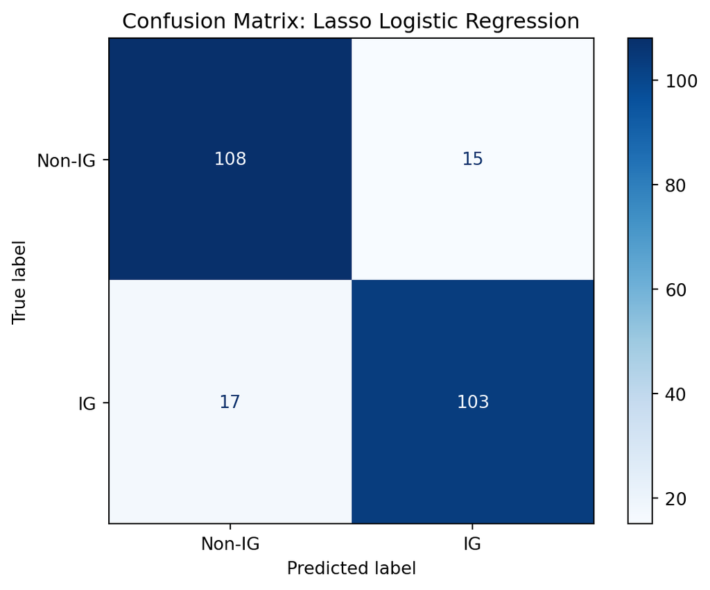

```python
# Get predictions
y_pred_lasso = lasso_model.predict(X_test_lasso_scaled)
y_pred_lasso_proba = lasso_model.predict_proba(X_test_lasso_scaled)[:, 1]

# Performance metrics
print(f'Accuracy: {accuracy_score(y_test_p2, y_pred_lasso):.4f}')
print(f'ROC-AUC: {roc_auc_score(y_test_p2, y_pred_lasso_proba):.4f}')
print(classification_report(y_test_p2, y_pred_lasso))

# Confusion matrix
cm_lasso = confusion_matrix(y_test_p2, y_pred_lasso)
disp = ConfusionMatrixDisplay(confusion_matrix=cm_lasso,
                               display_labels=['Non-IG', 'IG'])
disp.plot(cmap='Blues')
plt.title('Confusion Matrix: Lasso Logistic Regression')
plt.show()
```

#### Visualise the comparision between baseline and lasso model

```python
from sklearn.metrics import accuracy_score, roc_auc_score, f1_score, confusion_matrix

# Baseline metrics
cm_baseline = confusion_matrix(y_test_p2, y_pred)
baseline_fp = cm_baseline[0][1]
baseline_fn = cm_baseline[1][0]

# Lasso metrics
cm_lasso = confusion_matrix(y_test_p2, y_pred_lasso)
lasso_fp = cm_lasso[0][1]
lasso_fn = cm_lasso[1][0]

comparison = pd.DataFrame({
    'Metric': ['Accuracy', 'ROC-AUC', 'F1-Score', 'False Positives', 'False Negatives'],
    'Baseline': [
        round(accuracy_score(y_test_p2, y_pred), 4),
        round(roc_auc_score(y_test_p2, logit_model.predict(X_test_sm)), 4),
        round(f1_score(y_test_p2, y_pred), 4),
        baseline_fp,
        baseline_fn
    ],
    'Lasso (C = 1.0)': [
        round(accuracy_score(y_test_p2, y_pred_lasso), 4),
        round(roc_auc_score(y_test_p2, y_pred_lasso_proba), 4),
        round(f1_score(y_test_p2, y_pred_lasso), 4),
        lasso_fp,
        lasso_fn
    ]
})
display(comparison)
```

|  | Metric | Baseline | Lasso (C = 1.0) |
| --- | --- | --- | --- |
| 0 | Accuracy | 0.7613 | 0.8683 |
| 1 | ROC-AUC | 0.8410 | 0.9369 |
| 2 | F1-Score | 0.7642 | 0.8655 |
| 3 | False Positives | 32.0000 | 15.0000 |
| 4 | False Negatives | 26.0000 | 17.0000 |

The jump in ROC-AUC to 0.9369 indicates that the Lasso model is exceptionally capable of distinguishing between Investment Grade (IG) and non-IG sovereigns. The +10.7% increase in accuracy also support the that the degree of closeness between the predictions made by the alternative model and the actual category is higher.This suggests that the $L1$ penalty successfully filtered out the “noise” that was previously diluting the baseline’s predictive signals.

By comparing the number of false positives and false negatives between two models, we can see that the alternative model’s ability to slash False Positives by more than half is an outstanding improvement (FP: 32 -> 15, FN: 26 -> 17). Both false positives and false negatives decreased, suggesting the additional features genuinely improved discrimination in both directions. This is particularly relevant for financial risk management, as it reduces the likelihood of incorrectly labelling a high-risk sovereign as safe, potentially mitigating investor’s capital volatility.

## 2.5 Discussion

The Lasso model demonstrates that sovereign Investment Grade (IG) status is highly predictable, achieving an ROC-AUC of 0.937. This indicates a significantly more robust predictive signal than the baseline model. Sovereign credit status appears inherently more predictable than assets like gold returns because IG ratings are anchored in structural macroeconomic and institutional “levels” which evolve slowly. In contrast, commodity prices are often driven by volatile, speculative market sentiment that lacks the same underlying structural stability.

While the current model performs well, macroeconomic variables alone may not be sufficient for a comprehensive risk assessment. The model successfully identifies fiscal drivers, but it currently lacks data on geopolitical events, internal political instability, and real-time market sentiment. These factors can often serve as leading indicators for downgrades that occur before they are reflected in annual fiscal datasets.

A critical methodological limitation is the treatment of panel observations as independent. By treating each year for a country as a separate data point, the model ignores autocorrelation—the fact that a country’s status in one year is highly dependent on its status in the previous year. This violation of independence can lead to over-optimistic results, as the model essentially sees “near-duplicate” versions of the same country’s profile.

Additional limitations include multicollinearity among governance indicators, which resulted in unexpected coefficient sign flips, and the limited test set consisting of only two years. Future extensions could address these by using panel-aware models (fixed effects) to account for country-specific traits and time-series cross-validation to respect the temporal order of data. Integrating political risk indices or credit default swap (CDS) spreads would also provide a more holistic view of sovereign creditworthiness.

## 🤖 AI Tool Usage Declaration

In completing this assignment, I used the following AI tools:

- **Claude (Anthropic)** — Used throughout the assignment for guided learning, debugging code errors, understanding concepts (e.g. Lasso regularisation, precision-recall tradeoff), and proofreading markdown. Claude was used in a tutor capacity — it asked guiding questions rather than providing direct answers. All written interpretations, modelling decisions, and analytical conclusions are my own.